# Music Power Analysis

Stephanie, Leila, Annie, Nicholas

10/03/2022

Here, we will be documenting the simulation of our experiment design to test its statistical power. Our Power Analysis conducted demonstrates what sample size we need to have power in our final experiment with online ads. We will be testing the effect of having ads versus not having ads on the different social media platforms: Instagram, Facebook, Google, and Snapchat. We will also be testing the effect of whether the advertisement itself is a visual image or an informative piece of text.

Our scenarios include altering the treatment and control groups, adjusting the time of advertisements on each platform, altering the ads used, and increasing the group sizes. The ATE would be difference in average clicks for people receiving advertisements and those not receiving advertisements. We generated 3 separate data tables by varying the amount of simulated individuals in an attempt to determine which sample size would be most effective to perform power analysis on.

A published experiment1 testing the impact of native online advertising on persuasion surveyed a sample size of 77 individuals and measured statistically using a one-sided t-test. This experiment had a narrowed demographic of only Dutch people in a 20 age range. Their experiment focuses more on the persuasiveness of targeted ads so it measures impact of behavior on a likert scale whereas our experiment measures the impact of ads on engagement represented by clicks and subscriptions. Since we are testing on multiple platforms, we would also need a larger sample size - at least 4x the one mentioned in the study. However, we can also test our impact using a t-test.

For our power analysis, we will be using T-tests to test the impact of the treatment effect (having ads vs. no ads). We will also consider using multivariate regression with robust standard errors.

```r
library(data.table)
library(sandwich)
library(ggplot2)
```

Simulated 100 sample size

```r
sample_size = 100
d_100 <- data.table(personID = 1:sample_size)
d_100[, ':=' (experiment = sample(rep(c(0, 1), each = sample_size/2)),
            subscribed = sample(c(0:1), .N, replace=TRUE),
            clicks = sample(c(0:50), .N, replace=TRUE),
            prev_website_visits = sample(c(0:20), .N, replace=TRUE),
            ads_ran = sample(c(0:1000), .N, replace=TRUE),
            text_image = sample(c("text", "image"), .N, replace=TRUE),
            num_downloads = sample(c(0:30), .N, replace=TRUE),
            platforms = sample(c("Instagram", "Facebook (Meta)", "Snapchat", "Google"), .N, replace=TRUE))]
d_100[experiment == 0, text_image := "none"]
d_100[1:10]
```

```
##     personID experiment subscribed clicks prev_website_visits ads_ran
##  1:        1          1          1     16                   5     947
##  2:        2          0          0     18                  14     558
##  3:        3          1          0     26                   8     310
##  4:        4          1          1     10                  19     536
##  5:        5          1          1     24                   4     460
##  6:        6          0          1     10                   8     945
##  7:        7          0          0     35                   4     262
##  8:        8          1          0     15                  10      36
##  9:        9          1          0     27                   0     525
## 10:       10          1          0      7                  20     731
##     text_image num_downloads       platforms
##  1:      image            14       Instagram
##  2:       none            15       Instagram
##  3:       text            13       Instagram
##  4:       text             5          Google
##  5:      image             7          Google
##  6:       none            26        Snapchat
##  7:       none            19          Google
##  8:       text            22 Facebook (Meta)
##  9:       text             1          Google
## 10:       text             2          Google
```

Simulated 1000 sample size

```r
sample_size = 1000
d_1000 <- data.table(personID = 1:sample_size)
d_1000[, ':=' (experiment = sample(rep(c(0, 1), each = sample_size/2)),
            subscribed = sample(c(0:1), .N, replace=TRUE),
            clicks = sample(c(0:50), .N, replace=TRUE),
            prev_website_visits = sample(c(0:20), .N, replace=TRUE),
            ads_ran = sample(c(0:1000), .N, replace=TRUE),
            text_image = sample(c("text", "image"), .N, replace=TRUE),
            num_downloads = sample(c(0:30), .N, replace=TRUE),
            platforms = sample(c("Instagram", "Facebook (Meta)", "Snapchat", "Google"), .N, replace=TRUE))]
d_1000[experiment == 0, text_image := "none"]
d_1000[1:10]
```

```
##     personID experiment subscribed clicks prev_website_visits ads_ran
##  1:        1          1          1     13                  11     568
##  2:        2          1          0      9                   4     827
##  3:        3          0          0     20                  18     232
##  4:        4          1          1      6                  19     686
##  5:        5          1          0     45                  11     806
##  6:        6          1          1     21                  13     236
##  7:        7          0          1     23                  20     430
##  8:        8          0          0     23                   8     497
##  9:        9          1          0     19                  12      57
## 10:       10          1          0      2                   2     413
##     text_image num_downloads       platforms
##  1:       text            13        Snapchat
##  2:      image            19        Snapchat
##  3:       none             9 Facebook (Meta)
##  4:       text             6       Instagram
##  5:      image             5        Snapchat
##  6:      image             6          Google
##  7:       none            18        Snapchat
##  8:       none             6 Facebook (Meta)
##  9:      image            20          Google
## 10:       text            30          Google
```

Simulated 10000 sample size

```r
sample_size = 10000
d_10000 <- data.table(personID = 1:sample_size)
d_10000[, ':=' (experiment = sample(rep(c(0, 1), each = sample_size/2)),
            subscribed = sample(c(0:1), .N, replace=TRUE),
            clicks = sample(c(0:50), .N, replace=TRUE),
            prev_website_visits = sample(c(0:20), .N, replace=TRUE),
            ads_ran = sample(c(0:1000), .N, replace=TRUE),
            text_image = sample(c("text", "image"), .N, replace=TRUE),
            num_downloads = sample(c(0:30), .N, replace=TRUE),
            platforms = sample(c("Instagram", "Facebook (Meta)", "Snapchat", "Google"), .N, replace=TRUE))]
d_10000[experiment == 0, text_image := "none"]
d_10000[1:10]
```

```
##     personID experiment subscribed clicks prev_website_visits ads_ran
##  1:        1          1          1     24                  11     785
##  2:        2          0          0     39                  14      58
##  3:        3          0          0     32                   4     134
##  4:        4          1          0     30                   7     433
##  5:        5          1          0     22                  14     752
##  6:        6          1          0      9                   4     797
##  7:        7          0          1      8                  16      30
##  8:        8          1          1     35                  12     527
##  9:        9          1          0     34                  15     497
## 10:       10          1          1     15                   1     757
##     text_image num_downloads       platforms
##  1:      image            18        Snapchat
##  2:       none            11 Facebook (Meta)
##  3:       none            30       Instagram
##  4:      image             4 Facebook (Meta)
##  5:      image            15          Google
##  6:      image            12       Instagram
##  7:       none            30          Google
##  8:       text            15        Snapchat
##  9:      image            21        Snapchat
## 10:       text             0 Facebook (Meta)
```

Distribution of p_values for sample size 100

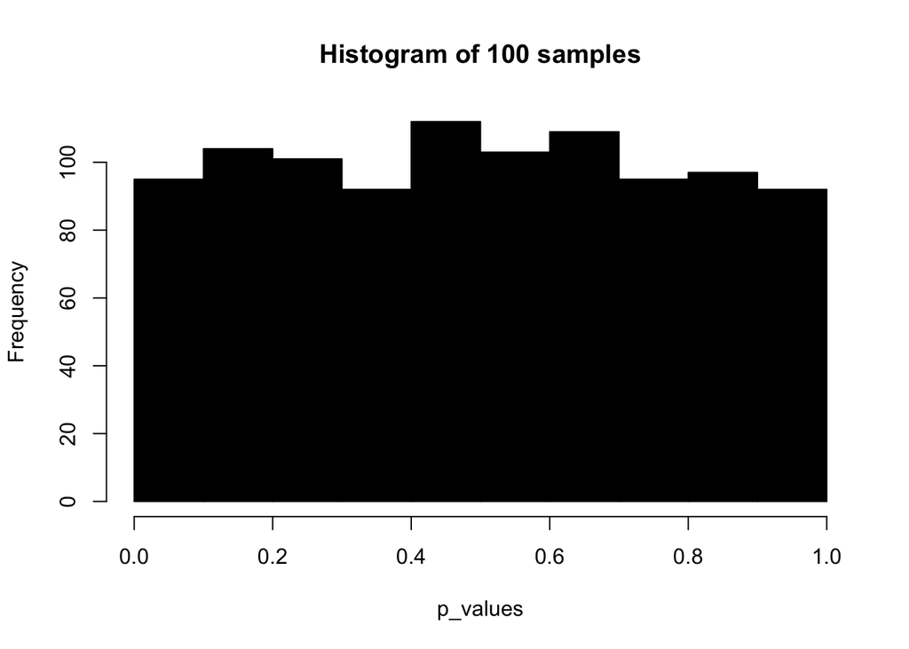

```r
p_values <- NA
for (i in 1:1000) {
  sampled_groups <- sample(d_100$experiment, length(d_100$experiment), replace=TRUE)
  #d[sample(experiment)]
  click_together = d_100$clicks * sampled_groups + d_100$clicks * (1-sampled_groups)
  p_values[i] <- t.test(click_together ~ sampled_groups)$p.value
}
hist(
  x = p_values,
  col = "black",
  main = "Histogram of 100 samples")
```

```r
power <- mean(abs(p_values) < 0.05)
power
```

```
## [1] 0.038
```

Distribution of p_values for sample size 1000

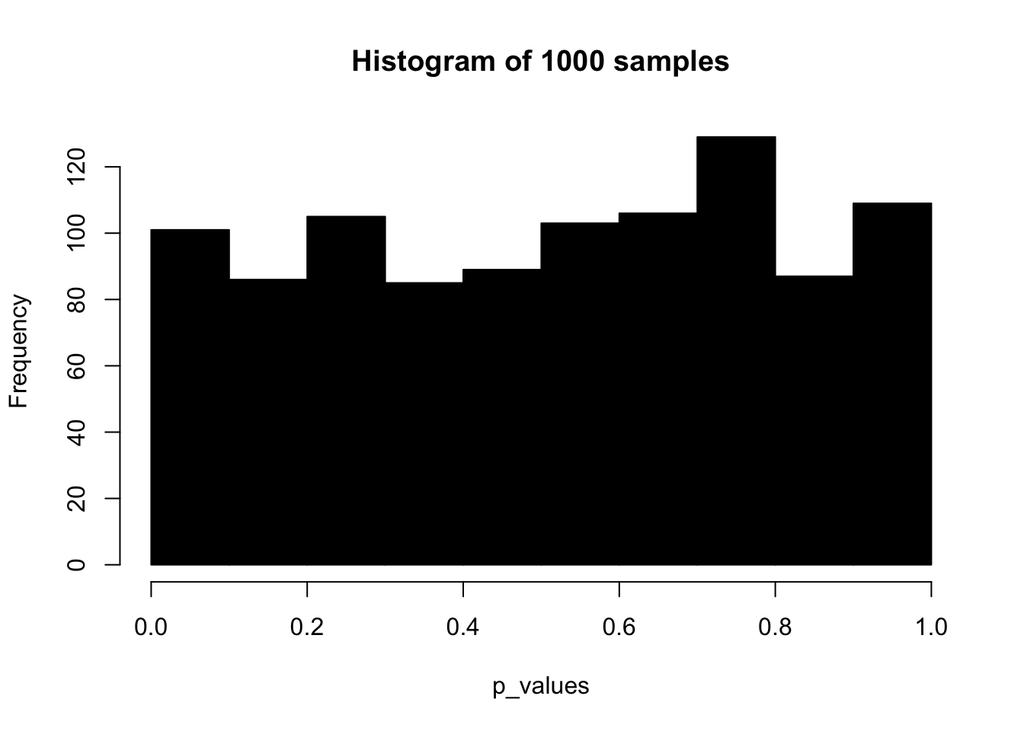

```r
p_values <- NA
for (i in 1:1000) {
  sampled_groups <- sample(d_1000$experiment, length(d_1000$experiment), replace=TRUE)
  #d[sample(experiment)]
  click_together = d_1000$clicks * sampled_groups + d_1000$clicks * (1-sampled_groups)
  p_values[i] <- t.test(click_together ~ sampled_groups)$p.value
}
hist(
  x = p_values,
  col = "black",
  main = "Histogram of 1000 samples")
```

```r
power <- mean(abs(p_values) < 0.05)
power
```

```
## [1] 0.055
```

Distribution of p_values for sample size 10000

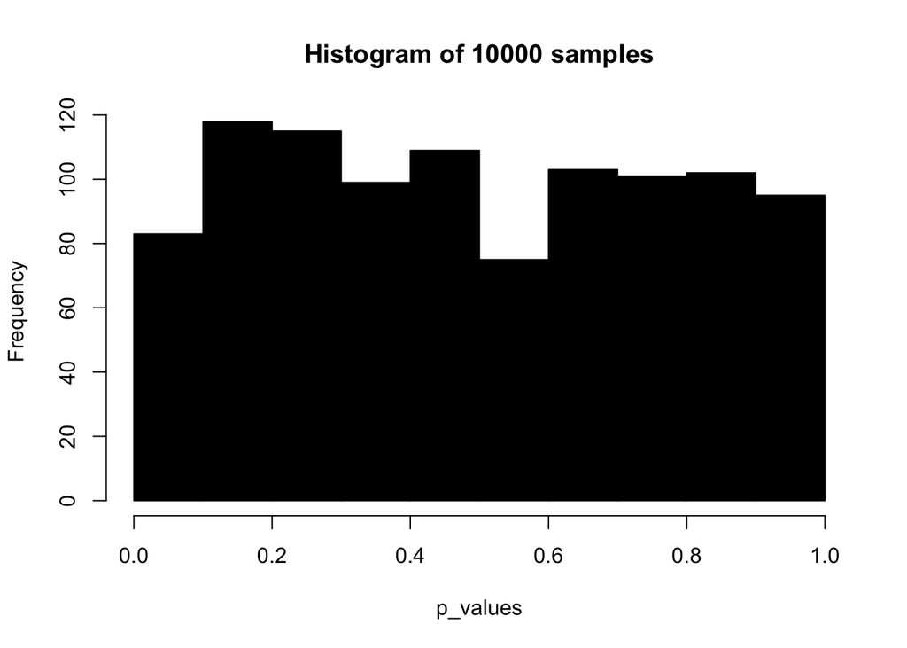

```r
p_values <- NA
for (i in 1:1000) {
  sampled_groups <- sample(d_10000$experiment, length(d_10000$experiment), replace=TRUE)
  #d[sample(experiment)]
  click_together = d_10000$clicks * sampled_groups + d_10000$clicks * (1-sampled_groups)
  p_values[i] <- t.test(click_together ~ sampled_groups)$p.value
}
hist(
  x = p_values,
  col = "black",
  main = "Histogram of 10000 samples")
```

```r
power <- mean(abs(p_values) < 0.05)
power
```

```
## [1] 0.041
```

```
#d_1000[, .(mean_clicks = mean(clicks)), key = text_image]
d_1000[, .(mean_clicks = mean(clicks)), keyby = .(experiment, platforms)]
```

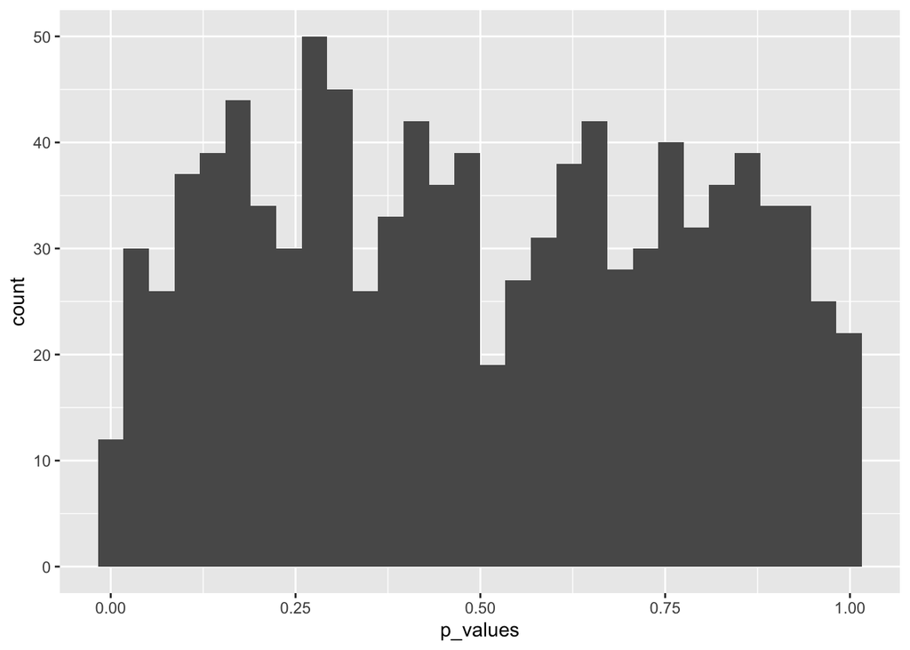

```r
ggplot() + aes(x = p_values) + geom_histogram()
```